# Problem6

Question 6 - Generate random numbers from the following distribution and visualize the data using violin plot. (i) Standard-Normal distribution. (ii) Log-Normal distribution.

```python
from matplotlib import pyplot as plt
import numpy as np
import seaborn as sns
import pandas as pd
import seaborn
```

```python
sn = np.random.normal(size=30)
ln = np.random.lognormal(3, 1, 30)
```

```python
sn
```

```
array([ 0.28541713, -0.22531605,  1.44666482, -0.57507284, -0.77195104,
       -0.18313683, -0.77114821, -1.6690251 , -1.09280601,  0.86323237,
       -0.93826435,  0.39453643,  1.47119839, -0.42240933,  0.81215559,
       -2.69948229, -0.65921609,  1.13511661,  0.50853072,  0.23665931,
        0.41525593,  0.91644692,  0.32870781,  0.46482661,  0.07584104,
        0.62611901,  0.59746301, -1.12369596, -1.45343376, -1.19338371])
```

```python
ln
```

```
array([ 59.24987514,  29.86976173,   9.70561493,   2.31917173,
         5.77165856,  20.52971338,   6.08510627,  58.81020413,
        29.30329401,   5.25904488,   3.14932901,  32.08563382,
        33.02622521,   9.3130104 ,  49.66563834,  12.66931881,
        16.16901541, 163.3886737 ,   5.10535737,  13.81986365,
        29.11496413,   0.874934  ,   2.43336628,  32.64475358,
        15.71152048,   9.50992083,  12.6915328 ,   3.38226099,
        14.4103571 ,  55.8233054 ])
```

```python
df = pd.DataFrame(sn, columns =  ['Standard Normal'])
df1 = pd.DataFrame(ln, columns =  ['Log Normal'])
```

Here are the violin plots for the distributions given above :-

For the Log Normal Distribution; In probability theory, a log-normal (or lognormal) distribution is a continuous probability distribution of a random variable whose logarithm is normally distributed. Thus, if the random variable X is log-normally distributed, then Y = ln(X) has a normal distribution.Equivalently, if Y has a normal distribution, then the exponential function of Y, X = exp(Y), has a log-normal distribution. A random variable which is log-normally distributed takes only positive real values. It is a convenient and useful model for measurements in exact and engineering sciences, as well as medicine, economics and other topics (e.g., energies, concentrations, lengths, financial returns and other metrics).

The distribution is occasionally referred to as the Galton distribution or Galton's distribution, after Francis Galton. The log-normal distribution has also been associated with other names, such as McAlister, Gibrat and Cobb–Douglas.

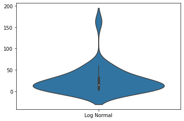

```python
sns.violinplot(data = df1)
```

For the Standard Normal Distribution; In probability theory, a normal (or Gaussian or Gauss or Laplace–Gauss) distribution is a type of continuous probability distribution for a real-valued random variable. Normal distributions are important in statistics and are often used in the natural and social sciences to represent real-valued random variables whose distributions are not known. Their importance is partly due to the central limit theorem. It states that, under some conditions, the average of many samples (observations) of a random variable with finite mean and variance is itself a random variable—whose distribution converges to a normal distribution as the number of samples increases. Therefore, physical quantities that are expected to be the sum of many independent processes, such as measurement errors, often have distributions that are nearly normal.

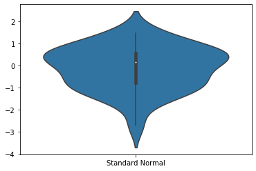

```python
sns.violinplot(data = df)
```